# PA2_SevereWeather

Cathy Snell

Monday, August 17, 2015

# US Severe Weather Events Population and Economic Impact Analysis

## Synopsis

This analysis uses the NOAA Storm Database to answer which weather events across the US are most harmful to populate health and have the greatest economic impact. The analysis focuses on the top weather events in each of 4 categories: fatalities, injuries, property damage and crop damage.

## Data Processing

### Database Details and Loading

The data source is the [NOAA STorm Database](http://d396qusza40orc.cloudfront.net/repdata%2Fdata%2FStormData.csv.bz2). Additional details around data collection and variable definitions are available:

- National Weather Service [Storm Data Documentation](http://d396qusza40orc.cloudfront.net/repdata%2Fpeer2_doc%2Fpd01016005curr.pdf)
- National Climatic Data Center Storm Events [FAQ](http://d396qusza40orc.cloudfront.net/repdata%2Fpeer2_doc%2FNCDC%20Storm%20Events-FAQ%20Page.pdf)

The events in the database start in the year 1950 and end in November 2011. In the earlier years of the database there are generally fewer events recorded, most likely due to a lack of good records. More recent years should be considered more complete.

The variables relevant to this analysis are:

- **EVTYPE**: Factor variable with weather event type such as “HAIL”, “TORNADO”, “TSTM WIND”
- **FATALITIES**: Number of fatalities per weather event
- **INJURIES**: Number of injuries per weather event
- **PROPDMG**: Property Damage in USD
- **PROPDMGEXP**: Factor indicating size of Property Damage dollars (“K”, “M”)
- **CROPDMG**: Crop Damage in USD
- **CROPDMGEXP**: Factor indicating size of Property Damage dollars (“K”, “M”)

Load the data. First we confirm the columns available, then load just what will be needed to save space.

```r
url <- "http://d396qusza40orc.cloudfront.net/repdata%2Fdata%2FStormData.csv.bz2"
temp <- tempfile()
download.file(url, temp)

## read.csv can handle compressed files automatically
storm <- read.csv(temp)[1, ]
storm
```

```
##   STATE__          BGN_DATE BGN_TIME TIME_ZONE COUNTY COUNTYNAME STATE
## 1       1 4/18/1950 0:00:00     0130       CST     97     MOBILE    AL
##    EVTYPE BGN_RANGE BGN_AZI BGN_LOCATI END_DATE END_TIME COUNTY_END
## 1 TORNADO         0                                               0
##   COUNTYENDN END_RANGE END_AZI END_LOCATI LENGTH WIDTH F MAG FATALITIES
## 1         NA         0                        14   100 3   0          0
##   INJURIES PROPDMG PROPDMGEXP CROPDMG CROPDMGEXP WFO STATEOFFIC ZONENAMES
## 1       15      25          K       0
##   LATITUDE LONGITUDE LATITUDE_E LONGITUDE_ REMARKS REFNUM
## 1     3040      8812       3051       8806              1
```

```r
## read in only the needed columns to save space
storm <- read.csv(temp)[, c('BGN_DATE', 'STATE', 'EVTYPE', 'FATALITIES', 'INJURIES',
                            'PROPDMG', 'PROPDMGEXP', 'CROPDMG', 'CROPDMGEXP')]
unlink(temp)
nrow(storm)
```

```
## [1] 902297
```

### Population Health Impact

We are interested in storms across the US, so all states will be considered.

To answer the first question, sum the total fatalies and injuries for each weather event type, filter to the most impactful to population health and view the output. There are 985 levels of the ENTYPE variable, so we will limit our view to the top 10 fatalities and injuries.

```r
fate <- aggregate(storm$FATALITIES, list(storm$EVTYPE), FUN=sum)
nrow(fate)
```

```
## [1] 985
```

```r
fate$Impact <- "Fatalities"

fate_sort <- fate[with(fate, order(-x)),]
head(fate_sort, 10)
```

```
##            Group.1    x     Impact
## 834        TORNADO 5633 Fatalities
## 130 EXCESSIVE HEAT 1903 Fatalities
## 153    FLASH FLOOD  978 Fatalities
## 275           HEAT  937 Fatalities
## 464      LIGHTNING  816 Fatalities
## 856      TSTM WIND  504 Fatalities
## 170          FLOOD  470 Fatalities
## 585    RIP CURRENT  368 Fatalities
## 359      HIGH WIND  248 Fatalities
## 19       AVALANCHE  224 Fatalities
```

```r
inj <- aggregate(storm$INJURIES, list(storm$EVTYPE), FUN=sum)
inj$Impact <- "Injuries"
inj_sort <- inj[with(inj, order(-x)), ]
head(inj_sort, 10)
```

```
##               Group.1     x   Impact
## 834           TORNADO 91346 Injuries
## 856         TSTM WIND  6957 Injuries
## 170             FLOOD  6789 Injuries
## 130    EXCESSIVE HEAT  6525 Injuries
## 464         LIGHTNING  5230 Injuries
## 275              HEAT  2100 Injuries
## 427         ICE STORM  1975 Injuries
## 153       FLASH FLOOD  1777 Injuries
## 760 THUNDERSTORM WIND  1488 Injuries
## 244              HAIL  1361 Injuries
```

We see some duplication of weather events even in this much reduced set of events with the highest fatalities and injuries. Additionally, as expected, the set of weather events varies some between the fatalities and injuries. To round things out, combine the duplicates and fill out any missing values.

Once clean, plot as a stacked barchart for visual comparison.

```r
pop_health <- rbind(fate_sort[1:10,], inj_sort[1:10,])
row.names(pop_health) <- c(1:nrow(pop_health))

## Remove the duplicate thunderstorm wind entries
pop_health[grep("M WIND", pop_health$Group.1),]
```

```
##              Group.1    x     Impact
## 6          TSTM WIND  504 Fatalities
## 12         TSTM WIND 6957   Injuries
## 19 THUNDERSTORM WIND 1488   Injuries
```

```r
pop_health[12,2] <- sum(pop_health[12,2], pop_health[19,2])
pop_health <- pop_health[c(1:18,20), ]

## Check to populate any missing values
inj[grep("AVALANCHE", inj$Group.1),]
```

```
##                           Group.1   x   Impact
## 19                      AVALANCHE 170 Injuries
## 323 HEAVY SNOW/BLIZZARD/AVALANCHE   1 Injuries
```

```r
pop_health <- rbind(pop_health, inj[19,])

hail <- fate[grep("HAIL", fate[,1]), ]
hail[hail[,2] > 0, ]
```

```
##                        Group.1  x     Impact
## 244                       HAIL 15 Fatalities
## 842 TORNADOES, TSTM WIND, HAIL 25 Fatalities
## 873             TSTM WIND/HAIL  5 Fatalities
```

```r
pop_health <- rbind(pop_health, fate[244,])

high_wind <- inj[grep("^HIGH WIND", inj$Group.1),]
high_wind[high_wind[,2] > 0, ]
```

```
##                  Group.1    x   Impact
## 359            HIGH WIND 1137 Injuries
## 361         HIGH WIND 48    1 Injuries
## 366   HIGH WIND AND SEAS   20 Injuries
## 371 HIGH WIND/HEAVY SNOW    1 Injuries
## 376           HIGH WINDS  302 Injuries
## 392      HIGH WINDS/COLD    4 Injuries
## 395      HIGH WINDS/SNOW    6 Injuries
```

```r
pop_health <- rbind(pop_health, inj[359,])
pop_health[21,2] <- sum(pop_health[21,2], inj[376,2])

ice <- fate[grep("ICE STORM", fate[,1]), ]
ice[ice[,2] > 0, ]
```

```
##       Group.1  x     Impact
## 427 ICE STORM 89 Fatalities
```

```r
pop_health <- rbind(pop_health, fate[427,])

rip <- inj[grep("RIP CURRENT", inj$Group.1),]
rip[rip[,2] > 0, ]
```

```
##          Group.1   x   Impact
## 585  RIP CURRENT 232 Injuries
## 586 RIP CURRENTS 297 Injuries
```

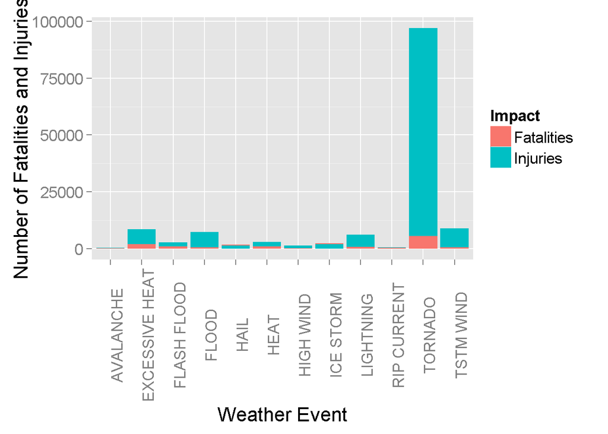

```r
pop_health <- rbind(pop_health, inj[585,])
pop_health[23,2] <- sum(pop_health[23,2], inj[586,2])

library(ggplot2)
ggplot(data=pop_health, aes(x=Group.1, y=x, fill=Impact)) +
    geom_bar(stat="identity") + xlab("Weather Event") +
    ylab("Number of Fatalities and Injuries") + theme(text = element_text(size=16),
        axis.text.x = element_text(angle=90, vjust=1))
```

### Economic Impact

To answer the second question, sum the total economic impact for each weather type, filter to the top impacting weather types and view the output.

Start by normalizing the property damage amounts to eliminate the differences between B, M, K, etc.

```r
prop <- storm[, c('EVTYPE', 'PROPDMG', 'PROPDMGEXP')]
table(prop$PROPDMGEXP)
```

```
##
##             -      ?      +      0      1      2      3      4      5
## 465934      1      8      5    216     25     13      4      4     28
##      6      7      8      B      h      H      K      m      M
##      4      5      1     40      1      6 424665      7  11330
```

```r
crop <- storm[, c('EVTYPE', 'CROPDMG', 'CROPDMGEXP')]
table(crop$CROPDMGEXP)
```

```
##
##             ?      0      2      B      k      K      m      M
## 618413      7     19      1      9     21 281832      1   1994
```

There are some unknown or non-standard values in PROPDMGEXP and CROPDMGEXP, but these are lower frequency, and so were not included in the totals.

```r
prop_b <- subset(prop, PROPDMGEXP == "B")
prop_b$norm_USD <- prop_b$PROPDMG*1000000000
prop_m <- subset(prop, PROPDMGEXP == "M" | PROPDMGEXP == "m")
prop_m$norm_USD <- prop_m$PROPDMG*1000000
prop_k <- subset(prop, PROPDMGEXP == "K" | PROPDMGEXP == "k")
prop_k$norm_USD <- prop_k$PROPDMG*1000
prop_0 <- subset(prop, PROPDMGEXP == "" | PROPDMGEXP == "0")
prop_0$norm_USD <- prop_0$PROPDMG

prop <- rbind(prop_m, prop_k, prop_0, prop_b)

prop_dmg <- aggregate(prop$norm_USD, list(prop$EVTYPE), FUN=sum)
prop_dmg$Impact <- "Property"
prop_dmg_sort <- prop_dmg[with(prop_dmg, order(-x)),]
head(prop_dmg_sort, 10)
```

```
##               Group.1            x   Impact
## 169             FLOOD 144657709807 Property
## 409 HURRICANE/TYPHOON  69305840000 Property
## 832           TORNADO  56937160617 Property
## 668       STORM SURGE  43323536000 Property
## 152       FLASH FLOOD  16140811979 Property
## 242              HAIL  15732267013 Property
## 400         HURRICANE  11868319010 Property
## 846    TROPICAL STORM   7703890550 Property
## 970      WINTER STORM   6688497251 Property
## 357         HIGH WIND   5270046260 Property
```

```r
crop_b <- subset(crop, CROPDMGEXP == "B")
crop_b$norm_USD <- crop_b$CROPDMG*1000000000
crop_m <- subset(crop, CROPDMGEXP == "M" | CROPDMGEXP == "m")
crop_m$norm_USD <- crop_m$CROPDMG*1000000
crop_k <- subset(crop, CROPDMGEXP == "K" | CROPDMGEXP == "k")
crop_k$norm_USD <- crop_k$CROPDMG*1000
crop_0 <- subset(crop, CROPDMGEXP == "" | CROPDMGEXP == "0")
crop_0$norm_USD <- crop_0$CROPDMG

crop <- rbind(crop_m, crop_k, crop_0, crop_b)

crop_dmg <- aggregate(crop$norm_USD, list(crop$EVTYPE), FUN=sum)
crop_dmg$Impact <- "Crop"
crop_dmg_sort <- crop_dmg[with(crop_dmg, order(-x)),]
head(crop_dmg_sort, 10)
```

```
##               Group.1           x Impact
## 95            DROUGHT 13972566000   Crop
## 169             FLOOD  5661968450   Crop
## 589       RIVER FLOOD  5029459000   Crop
## 426         ICE STORM  5022113500   Crop
## 243              HAIL  3025954473   Crop
## 401         HURRICANE  2741910000   Crop
## 410 HURRICANE/TYPHOON  2607872800   Crop
## 153       FLASH FLOOD  1421317100   Crop
## 140      EXTREME COLD  1292973000   Crop
## 211      FROST/FREEZE  1094086000   Crop
```

Once clean, plot as a stacked barchart for visual comparison.

```r
econ_imp <- rbind(prop_dmg_sort[1:10,], crop_dmg_sort[1:10,])
row.names(econ_imp) <- c(1:nrow(econ_imp))

## Combine the hurricane entries
econ_imp[grep("HURRICANE", econ_imp$Group.1),]
```

```
##              Group.1           x   Impact
## 2  HURRICANE/TYPHOON 69305840000 Property
## 7          HURRICANE 11868319010 Property
## 16         HURRICANE  2741910000     Crop
## 17 HURRICANE/TYPHOON  2607872800     Crop
```

```r
econ_imp[2,2] <- sum(econ_imp[2,2], econ_imp[7,2])
econ_imp[17,2] <- sum(econ_imp[17,2], econ_imp[16,2])
econ_imp <- econ_imp[c(1:6,8:15,17:20), ]
row.names(econ_imp) <- c(1:nrow(econ_imp))

## Combine extreme cold and frost/freeze
econ_imp[grep("FROST", econ_imp$Group.1),]
```

```
##         Group.1          x Impact
## 18 FROST/FREEZE 1094086000   Crop
```

```r
econ_imp[grep("EXTREME COLD", econ_imp$Group.1),]
```

```
##         Group.1          x Impact
## 17 EXTREME COLD 1292973000   Crop
```

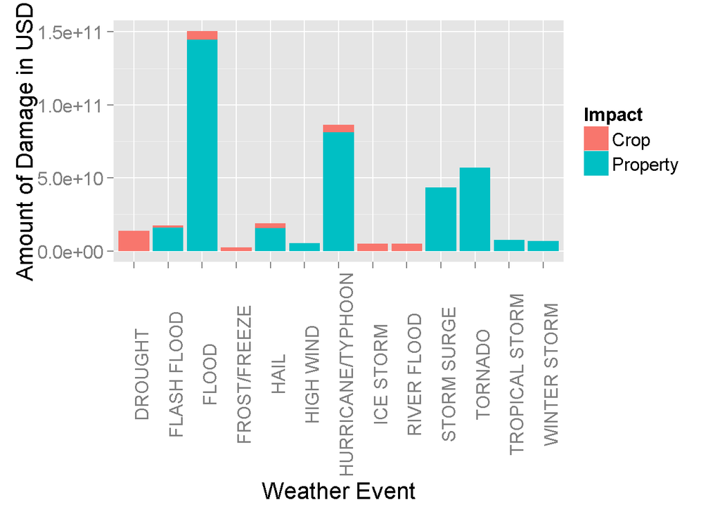

```r
econ_imp[18,2] <- sum(econ_imp[18,2], econ_imp[17,2])
econ_imp <- econ_imp[c(1:16,18), ]

ggplot(data=econ_imp, aes(x=Group.1, y=x, fill=Impact)) +
    geom_bar(stat="identity") + xlab("Weather Event") +
    ylab("Amount of Damage in USD") + theme(text = element_text(size=16),
        axis.text.x = element_text(angle=90, vjust=1))
```

## Results

By examining the top 10 most harmful weather types across four different categories of fatalities, injuries, property damage and crop damage, we see that tornados have the greatest impact on population health and floods have the greatest economic impact.